# Univariate Plots Section

> **Tip**: This is Financial Contributions to Presidential Campaigns in WA data set from http://classic.fec.gov/disclosurep/PDownload.do.

```
## 'data.frame':    292317 obs. of  9 variables:
##  $ cand_nm          : Factor w/ 24 levels "Bush, Jeb","Carson, Benjamin S.",..: 4 19 19 4 4 22 19 4 19 19 ...
##  $ contbr_nm        : Factor w/ 49817 levels "'CALL, ALLAN",..: 11139 23477 26330 15549 13027 34466 26698 20215 24250 24250 ...
##  $ contbr_city      : Factor w/ 718 levels "1644 WINDEMERE DR.",..: 494 559 559 300 559 629 320 575 242 242 ...
##  $ contbr_zip       : Factor w/ 53471 levels "00159","00160",..: 38468 12153 22415 7521 16516 39785 36565 24928 35809 35809 ...
##  $ contbr_employer  : Factor w/ 13372 levels "''I LIKE COMICS''",..: NA 7616 10387 NA 4978 5403 7760 10062 7760 7760 ...
##  $ contbr_occupation: Factor w/ 8259 levels "-"," CERTIFIED REGISTERED NURSE ANESTHETIS",..: 2110 4692 7484 6163 2159 3513 4692 5706 4692 4692 ...
##  $ contb_receipt_amt: num  25 27 50 55 18.9 ...
##  $ contb_receipt_dt : Factor w/ 671 levels "01-APR-15","01-APR-16",..: 505 78 121 414 350 212 121 414 78 121 ...
##  $ election_tp      : Factor w/ 4 levels "G2016","O2016",..: 3 3 3 3 3 1 3 3 3 3 ...
```

```
##                       cand_nm                    contbr_nm
##  Clinton, Hillary Rodham  :126190   BUNSON, JAMIE     :   282
##  Sanders, Bernard         :121555   TREIBEL, RANDY    :   280
##  Trump, Donald J.         : 16222   BUCKLEY, MARK     :   262
##  Cruz, Rafael Edward 'Ted': 13357   WATSON, DONNA     :   256
##  Carson, Benjamin S.      :  8085   BENACK, MARY ANN  :   214
##  Rubio, Marco             :  2192   SOMERVILLE, DALENE:   191
##  (Other)                  :  4716   (Other)           :290832
##      contbr_city         contbr_zip          contbr_employer
##  SEATTLE   : 82399   98053    :   286   NONE         : 28069
##  VANCOUVER :  9555   981556413:   161   RETIRED      : 26858
##  OLYMPIA   :  8965   98033    :   156   SELF-EMPLOYED: 15757
##  BELLINGHAM:  8105   98004    :   152   NOT EMPLOYED : 15214
##  TACOMA    :  8075   981882718:   145   SELF         :  8269
##  (Other)   :175214   (Other)  :291377   (Other)      :155422
##  NA's      :     4   NA's     :    40   NA's         : 42728
##              contbr_occupation  contb_receipt_amt   contb_receipt_dt
##  RETIRED              : 58036   Min.   :-8432.99   31-MAR-16:  3443
##  NOT EMPLOYED         : 38766   1st Qu.:   15.00   29-FEB-16:  3323
##  INFORMATION REQUESTED:  6361   Median :   27.00   31-MAY-16:  2576
##  SOFTWARE ENGINEER    :  5494   Mean   :   82.95   30-MAR-16:  2549
##  TEACHER              :  5035   3rd Qu.:   60.00   30-APR-16:  2540
##  (Other)              :176308   Max.   :10800.00   09-MAR-16:  2312
##  NA's                 :  2317                      (Other)  :275574
##  election_tp
##  G2016: 89381
##  O2016:   109
##  P2016:202462
##  P2020:     1
##  NA's :   364
##
##
```

In 2016 Presidential Campaign Finance, contributor raw data in WA have 292317 observations and 19 variables, each observation records a donation transaction. And then I delete 10 columns by python. So the data import to R have 9 variables and 292317 observations.

```
##     Min.  1st Qu.   Median     Mean  3rd Qu.     Max.
## -8432.99    15.00    27.00    82.95    60.00 10800.00
```

summary the contb_receipt_amt and find that there are some minus value. Obviously, we need to delete these observations.

```
## [1] 289340      9
```

now the data set have 289340 observations.

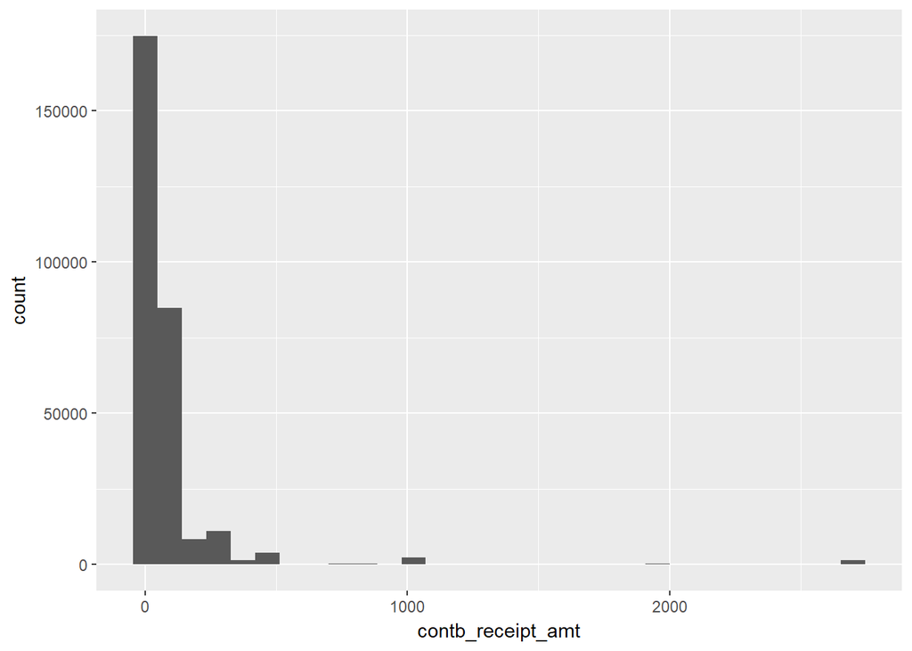

obviously, most donate amount are small and there are some extremely high amount value outliers. Consequently, it is neccessary to use log10 transform for better distribution histogram.

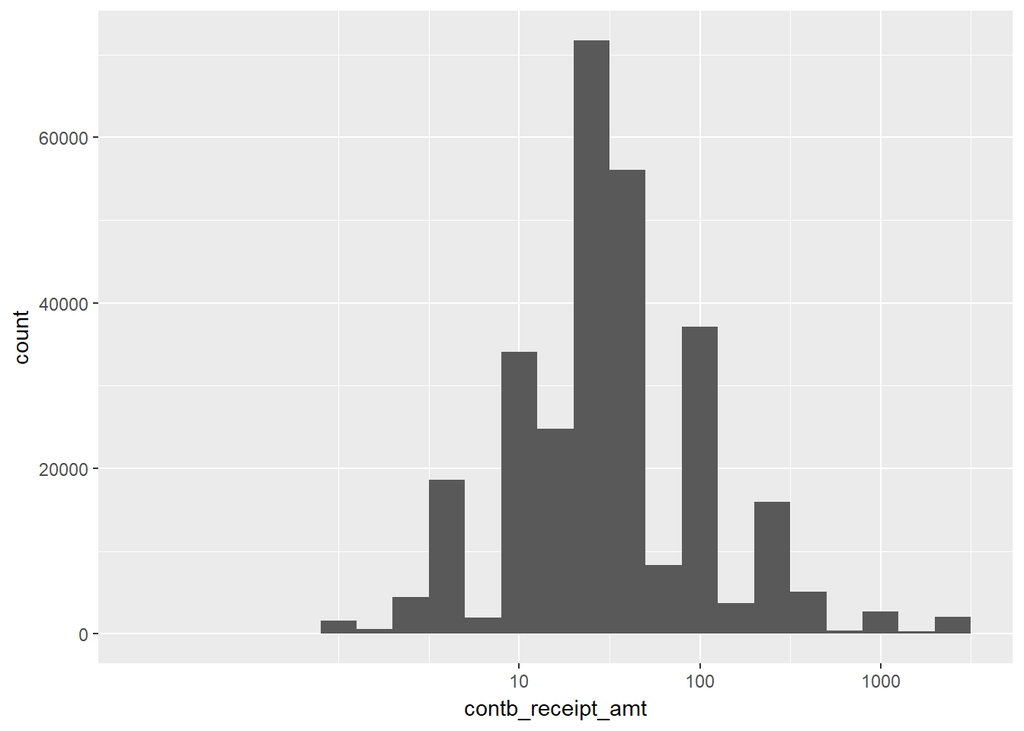

After using log to scale contb_receipt_amt, the contribution seems to become normal. And then I will try to use shapiro test to test the log normality of contb_teceipt_amt. As the chart shows, the distribution of contb_receipt_amt is not smooth and have several peak. Accordingly, I decide to facet the chart to three peices.

```
##
##  Shapiro-Wilk normality test
##
## data:  log_normal_sample
## W = 0.97459, p-value < 0.00000000000000022
```

Though the W is almost 1, but the p-value is too small. That is to say the Shapiro-Wilk normality test shows that contb_receipt_amt is not log normal distribution.

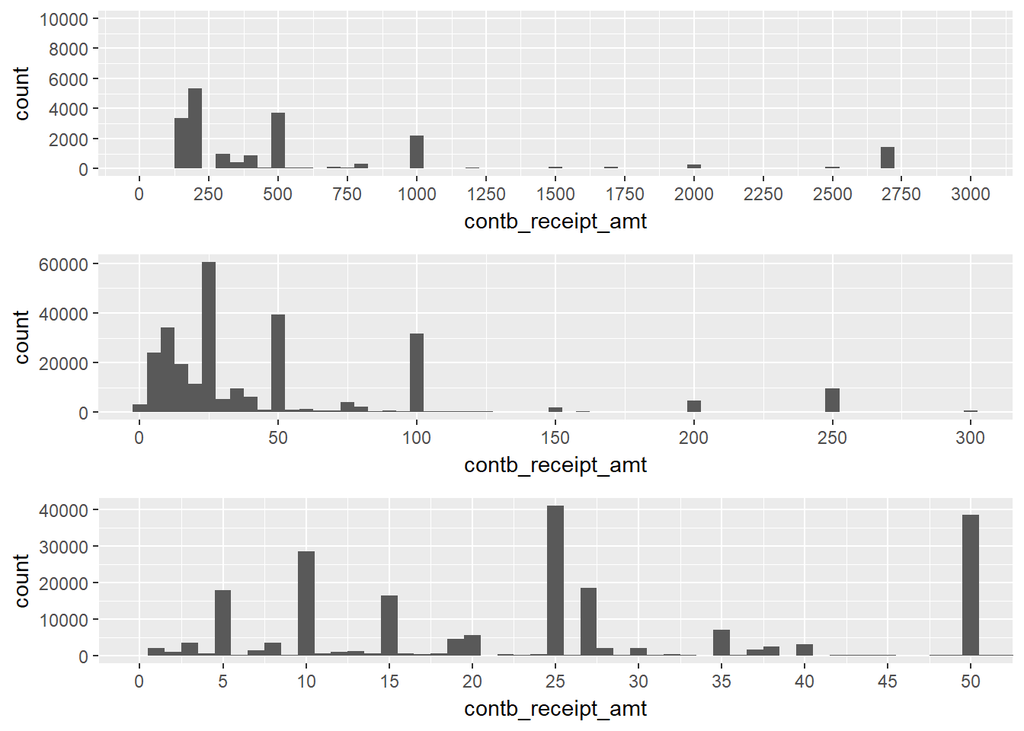

The faceting charts shows that the contribution are focus on several point, such as 25 50, 100. It make sense, people will seldom donate money like 7, 21 or 123. The another thing we can notice it that the majority of contributions are small money. Besides, there is a small peak at 2700 since this is the ceiling of contribution.

```
## 80%
## 100
```

we can see that 80% of the donates are less than 100$.

And then, I need to add more variables to explore potential interesting pattern.

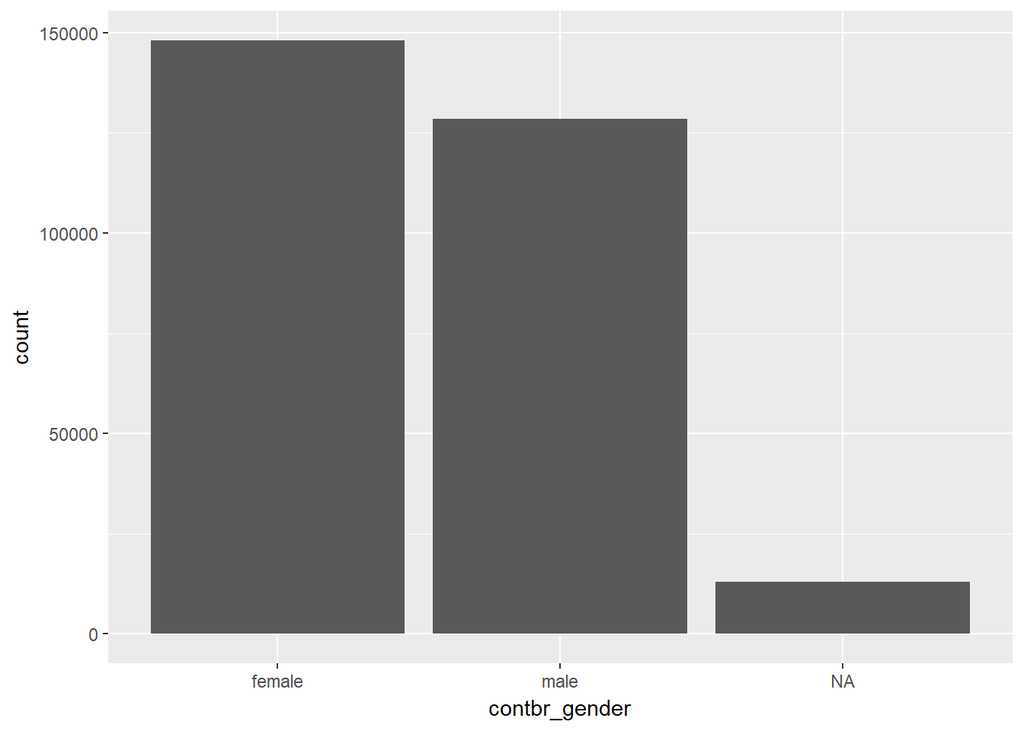

```
##
## female   male
## 148058 128403
```

Number of male and female contributors.

There is some NA, maybe value missing or transgender or whatever. Anyway, I will just remove the NA when analyzing something relating to gender.

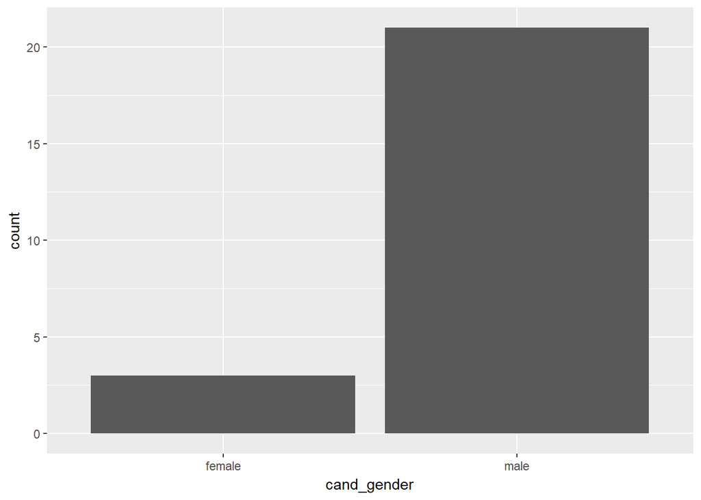

```
##
## female   male
##      3     21
```

Here is the chart about candidate gender count. We can see that the number of male candidates overwhelms female’s.

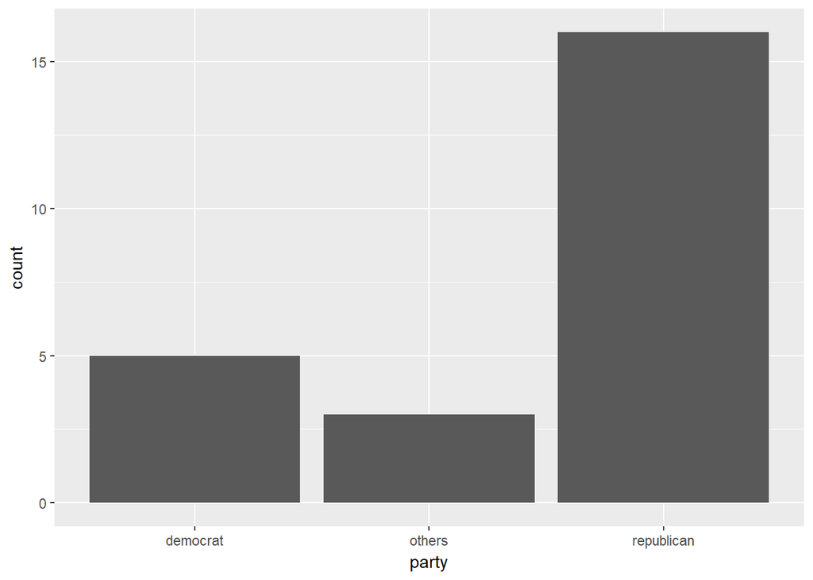

```
##
##   democrat     others republican
##          5          3         16
```

Number of party candidates.

It can be seen from the graph that the number of republican candidate overwhelm democrat’s.

But as we all konw now, the Democrat, Hillary win the Washington state.

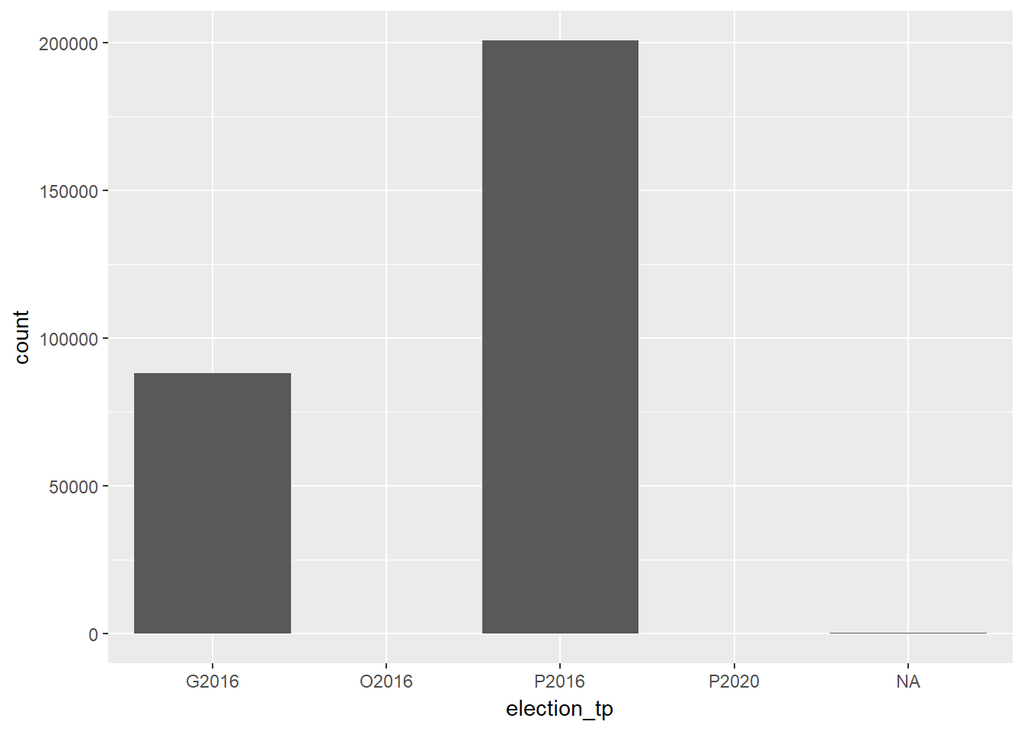

The graph shows that the contribution of Primary is more than twice as much as the double general.

```
## [1] 716   2
```

```
##    Min. 1st Qu.  Median    Mean 3rd Qu.    Max.
##     1.0     1.0    14.5   404.1   133.0 81773.0
```

```
##     95%
## 1424.25
```

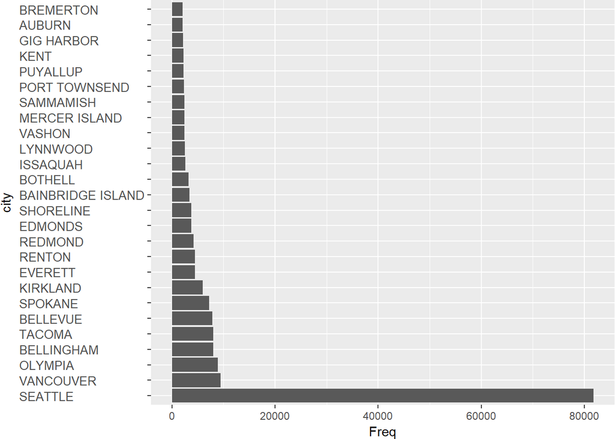

No surprise, the outstanding bar is Seattle.

```
##     Min.  1st Qu.   Median     Mean  3rd Qu.     Max.
##     1.00     1.00     4.00    35.04    11.00 57491.00
```

```
## [1] 8244    2
```

```
## 95%
##  59
```

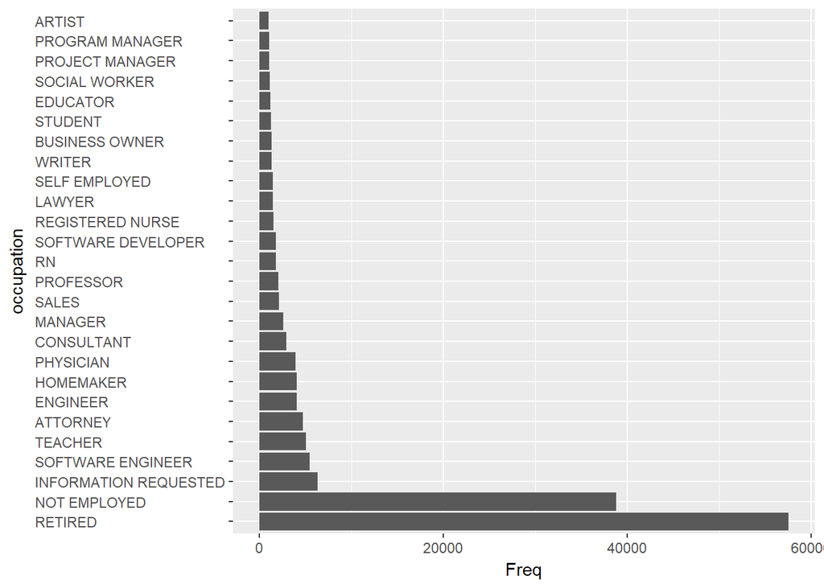

According to the figure, the top2 occupation retired and notemployed are far more than others.

So, I decide to see what percentile are the top2 occupation.

```
##          n
## 1 0.198697
```

```
##           n
## 1 0.1339497
```

That is high. It seems not good that 1/3 of the contribution are made by retired and not employed people since they exactly do not have income. That figure is obviously higher than their percent in total population. In other word, the young employees are less active in election. It is weird.

```
##    Min. 1st Qu.  Median    Mean 3rd Qu.    Max.
##     1.0    16.0    93.0   447.8   538.2  7654.0
```

```
## [1] 646   2
```

There 646 different zipcode.

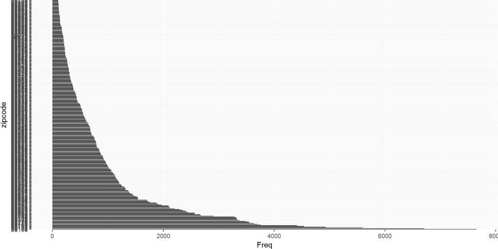

I just want to see the distribution of zipcode here. I assumed that it will just look like the city freq chart, having a few max outliers. But it is more smooth than city freq chart.

Moreover, I add additional variables about demographic data to the dataset.

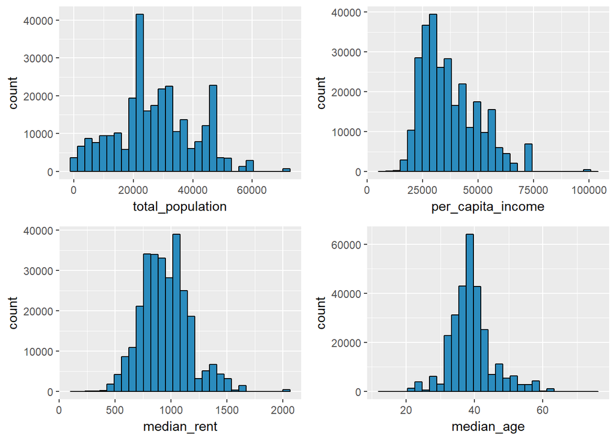

From the figures, we can see contributor’s demographic distribution divided by zipcode.

```
##
##  Shapiro-Wilk normality test
##
## data:  normal_sample
## W = 0.98395, p-value < 0.00000000000000022
```

```
##
##  Shapiro-Wilk normality test
##
## data:  normal_sample
## W = 0.94319, p-value < 0.00000000000000022
```

```
##
##  Shapiro-Wilk normality test
##
## data:  normal_sample
## W = 0.98174, p-value < 0.00000000000000022
```

```
##
##  Shapiro-Wilk normality test
##
## data:  normal_sample
## W = 0.94666, p-value < 0.00000000000000022
```

Shapiro-Wilk normality test shows that none of them is normal distribution.

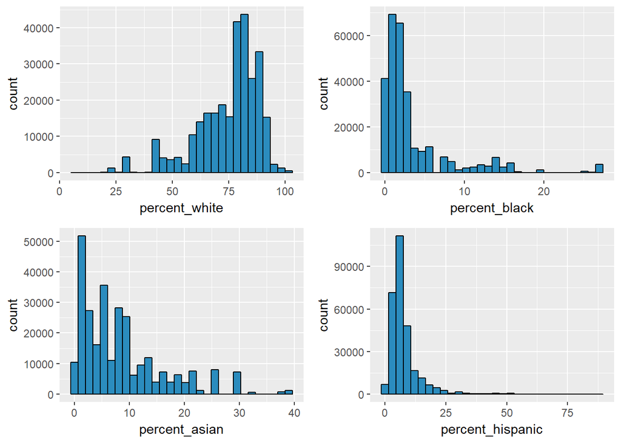

No suprise, most of the percent_white are 75 percent or more.

# Univariate Analysis

### What is the structure of your dataset?

There are 5 derived variables:  
* party  
* cand_first_nm  
* cand_gender  
* contbr_first_nm  
* contbr_gender

There are 8 demographic variables coming from df_zip_demographics data set:  
* total_population  
* percent_white  
* percent_black  
* percent_asian  
* percent_hispanic  
* per_capita_income  
* median_rent  
* median_age

There are a lot of categorical but no ordered factor.

### What is/are the main feature(s) of interest in your dataset?

The main features of interest in the data set are contbr_amt, party, cand_name, contbr_gender, total_population, per_capita_income, percent_white and median_age. I hope these variables can be used to build a predictive model to predict contribution amount to which party.

### What other features in the dataset do you think will help support your investigation into your feature(s) of interest?

I think contbr_zip, contbr_occupation, contb_receipt_dt, cand_gender, median_rent, percent_black, ercent_asian, percent_hispanic, election_tp are all relevant to contribution amount.

### Did you create any new variables from existing variables in the dataset?

There are 5 derived variables:  
* party  
* cand_first_nm  
* cand_gender  
* contbr_first_nm  
* contbr_gender

cand_name >- party  
cand_name >- cand_first_nm >- cand_gender  
contbr_nm >- contbr_first_nm >- contbr_gender

### Of the features you investigated, were there any unusual distributions? Did you perform any operations on the data to tidy, adjust, or change the form of the data? If so, why did you do this?

The contribution have amount less than 0 and larger than 2700, which is illegal. I just remove these rows.

The largest three group of contributors by occupation are retirees, NOT EMPLOYED and INFORMATION REQUESTED.

The election type have one blank type, no idea what it is.

# Bivariate Plots Section

```
##
## Two-Step Estimates
##
## Correlations/Type of Correlation:
##                   contb_receipt_amt election_tp      party contbr_gender
## contb_receipt_amt                 1  Polyserial Polyserial    Polyserial
## election_tp                 -0.1306           1 Polychoric    Polychoric
## party                        0.1416      0.1322          1    Polychoric
## contbr_gender               0.05029      0.1461     0.2105             1
## cand_gender                 -0.1069      0.7928     0.6604        0.2822
## total_population           -0.01535    -0.03834   -0.08894     -0.005546
## percent_white             -0.003382     0.06254    0.09549      -0.03793
## percent_black             -0.004513    -0.05848    -0.1677       0.02963
## percent_asian               0.04397     -0.1195    -0.1907       0.02969
## percent_hispanic           -0.02551     0.03468     0.1477       0.02524
## per_capita_income            0.1281     -0.1594    -0.2255      0.009427
## median_rent                 0.09358     -0.1322    -0.1687      0.008477
## median_age                 0.000398     0.05734    0.07465      -0.04584
## time                       -0.01311     -0.9478    -0.2195       -0.1317
##                   cand_gender total_population percent_white percent_black
## contb_receipt_amt  Polyserial          Pearson       Pearson       Pearson
## election_tp        Polychoric       Polyserial    Polyserial    Polyserial
## party              Polychoric       Polyserial    Polyserial    Polyserial
## contbr_gender      Polychoric       Polyserial    Polyserial    Polyserial
## cand_gender                 1       Polyserial    Polyserial    Polyserial
## total_population     -0.05531                1       Pearson       Pearson
## percent_white         0.08904          -0.3092             1       Pearson
## percent_black         -0.1167           0.1375        -0.779             1
## percent_asian          -0.176           0.3107       -0.7562         0.566
## percent_hispanic       0.0887           0.1888       -0.5286         0.152
## per_capita_income     -0.2564         -0.05413        0.1658       -0.1165
## median_rent            -0.196           0.1806      -0.02378      -0.06753
## median_age            0.08311          -0.5196        0.4169       -0.2524
## time                  -0.7365          0.03625      -0.04127       0.04434
##                   percent_asian percent_hispanic per_capita_income
## contb_receipt_amt       Pearson          Pearson           Pearson
## election_tp          Polyserial       Polyserial        Polyserial
## party                Polyserial       Polyserial        Polyserial
## contbr_gender        Polyserial       Polyserial        Polyserial
## cand_gender          Polyserial       Polyserial        Polyserial
```

[output cut: 9 more lines]

```
##                   median_rent median_age       time
## contb_receipt_amt     Pearson    Pearson    Pearson
## election_tp        Polyserial Polyserial Polyserial
## party              Polyserial Polyserial Polyserial
## contbr_gender      Polyserial Polyserial Polyserial
## cand_gender        Polyserial Polyserial Polyserial
## total_population      Pearson    Pearson    Pearson
## percent_white         Pearson    Pearson    Pearson
## percent_black         Pearson    Pearson    Pearson
## percent_asian         Pearson    Pearson    Pearson
## percent_hispanic      Pearson    Pearson    Pearson
## per_capita_income     Pearson    Pearson    Pearson
## median_rent                 1    Pearson    Pearson
## median_age           -0.09298          1    Pearson
## time                  0.07734   -0.04617          1
```

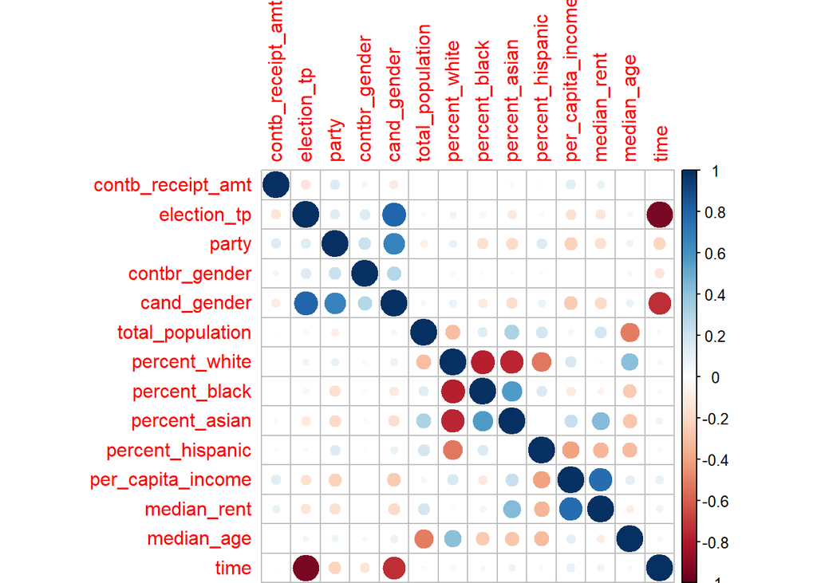

First, I just output the correlation matrix and then plot it, the higher the correlation, the bigger the circle.

With the help of the matrix plot, I can easily distinguish those high correlations and confirm the real correlation value by the correlation matrix.

Here are some interesting correlation:

contb_receipt_amt and party have 0.135 correlation  
contb_receipt_amt and election_tp have -0.105 correlation  
contb_receipt_amt and per_capital_income have 0.133 correlation  
cand_gender and contbr_gender have 0.339 correlation  
cand_gender and per_capita_income have -0.214 correlation  
party and per_capita_income have -0.216 correlation  
party and percent_black have -0.154 correlation  
party and percent_asian have -0.181 correlation  
party and percent_hispanic have 0.146 correlation  
total_population and median_age have -0.523 correlation  
total_popultation and percent_white have -0.316 correlation  
total_popultation and percent_black 0.139 correlation  
total_popultation and percent_asian have 0.31 correlation  
total_popultation and percent_hispanic have 0.199 correlation  
percent_white and percent_black have -0.777 correlation  
percent_white and percent_asian have -0.755 correlation  
percent_white and percent_hispanic have -0.531 correlation  
percent_asian and per_capita_income have 0.232 correlation  
percent_asian and median_rent have 0.437 correlation  
percent_asian and median_age have -0.28 correlation  
percent_hispanic and median_rent have -0.328 correlation  
percent_hispanic and median_age have -0.318 correlation  
percent_hispanic and per_capita_income have -0.409 correlation  
per_capita_income and median_rent have 0.762 correlation

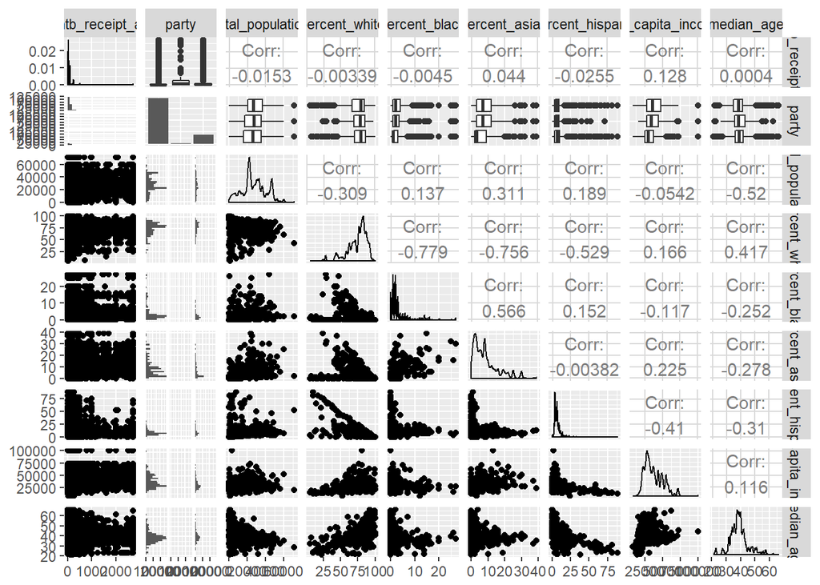

And then I use ggpair to make a matrix of plots to visualize the relation between all pair of variables and the distribution of variables.

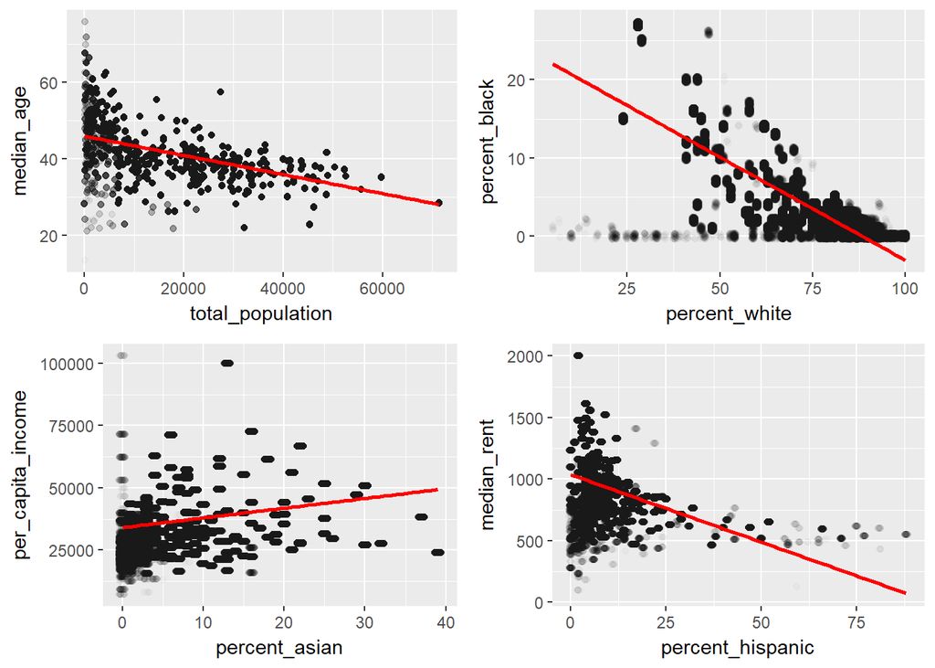

Some interesting demographic relation. We can conclude from the first graph that the big city have more young people. The others are aboout ethnic.

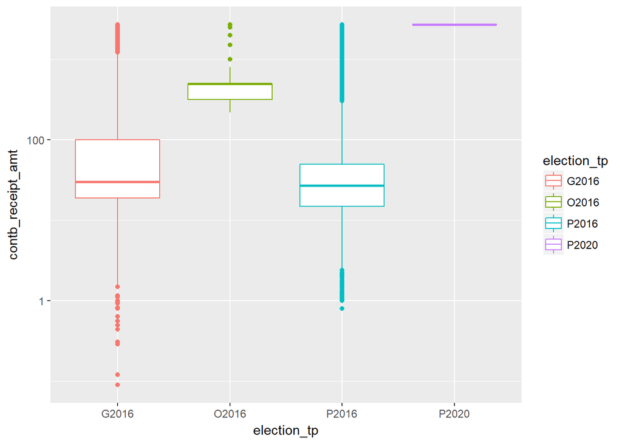

```
##       contbr_zip cand_first_nm contbr_first_nm            cand_nm
## 74932      98104       Lindsey             JIM Graham, Lindsey O.
##          contbr_nm contbr_city contbr_employer contbr_occupation
## 74932 ALBAUGH, JIM     SEATTLE         RETIRED           RETIRED
##       contb_receipt_amt contb_receipt_dt election_tp      party
## 74932              2700       2016-01-15       P2020 republican
##       contbr_gender cand_gender total_population percent_white
## 74932          male        male            12871            45
##       percent_black percent_asian percent_hispanic per_capita_income
## 74932            15            26                8             29533
##       median_rent median_age       time
## 74932         760       40.8 1452816000
```

We can see that the only one contribution to 2020 primary election is from a retired to Graham, Lindsey O. with $2700.

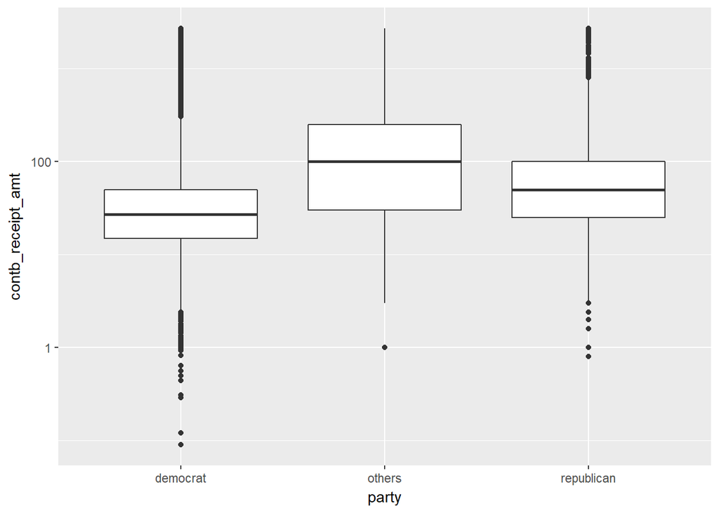

From this chart, We can see that the Republican have higher average contribution.

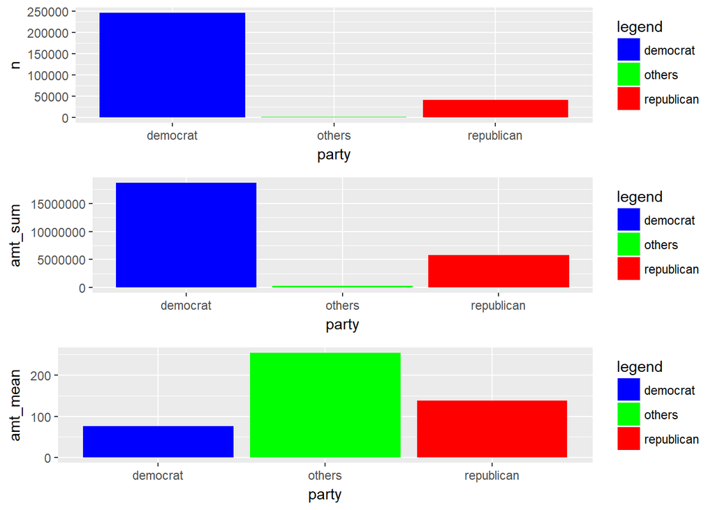

But from these charts we can illustrates that Democrat overwhlems Republican about the number of contribution so that Democrat also overwhlems Republican about the total contribution.

We can also cross-validate from the last bar chart that the average contribution of Republican is highr than Democrat’s. But the other parties have the highest average contribution.

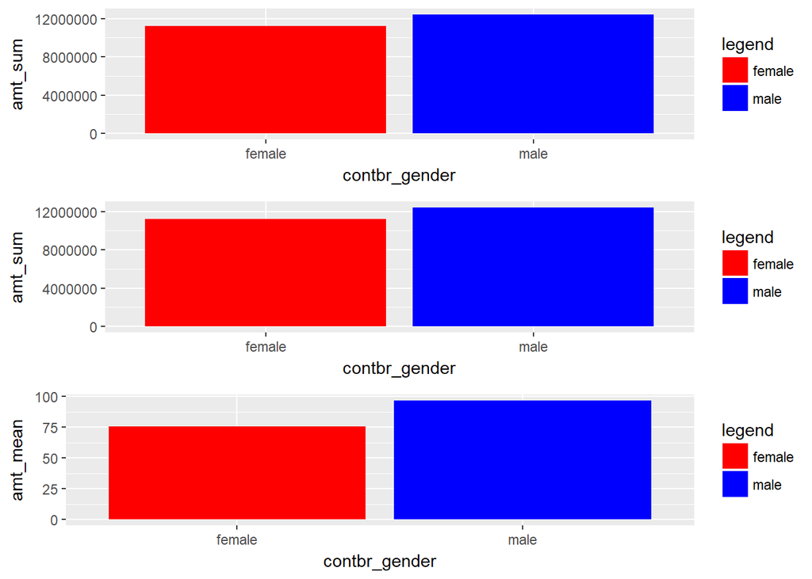

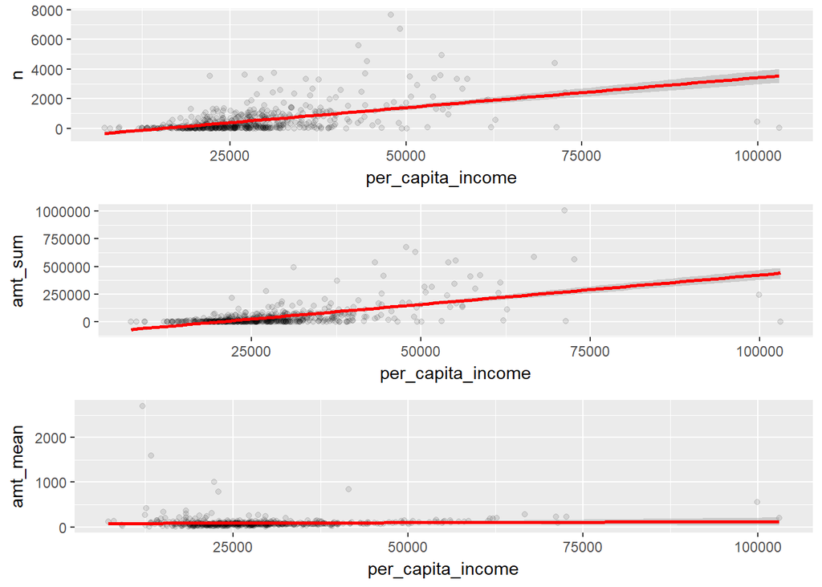

It shows that people have around 50000 income make most contributions, but people have about 70000 income make the most total contribution.

And the more per capita income, the more contribution, but the average contribution almost the same.

The median contribution peak at low income seems very strange.

```
##        cand_first_nm contbr_gender contb_receipt_amt per_capita_income
## 134674          Rand          male              2700             15981
## 214296       Hillary          <NA>              2700             16805
## 214322       Hillary          <NA>              2700             16805
## 219627       Hillary          male              2650             18715
## 261321       Bernard          male              2700             19278
## 261346       Bernard          <NA>              2700             19278
## 263829       Hillary        female              2700             17011
## 263934        Donald          male              2700             17980
## 264070        Donald        female              2700             17980
## 266774       Hillary          male              2700             15363
## 267410       Hillary          <NA>              2700             12484
## 271767       Hillary          <NA>              2700             12101
## 281689        Donald        female              2067             19567
## 281952        Donald          male              2700             19567
```

[output cut: 27 more lines]

Acoordingly, I output these observation with some selected variables.

The figures shows that most of the contributions are donated to Hillary and Trump! What is more, most of the Hillary contributor did not leave their occupation information. In contrast, among 9 Trump contributors, 5 are farmer!

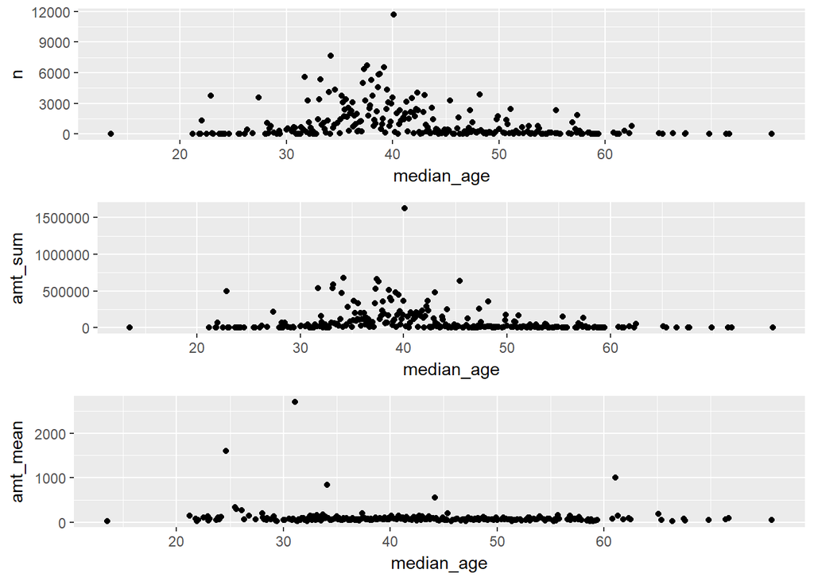

It shows that people about 40 make the most number of contribution and highest total contribution, but the people about 30 make the highest mean contribution. There also two other peaks at 25 and 60 in median amount plot.

In addition, I Group the contb_receipt_amt by contribution by ethnic structure.

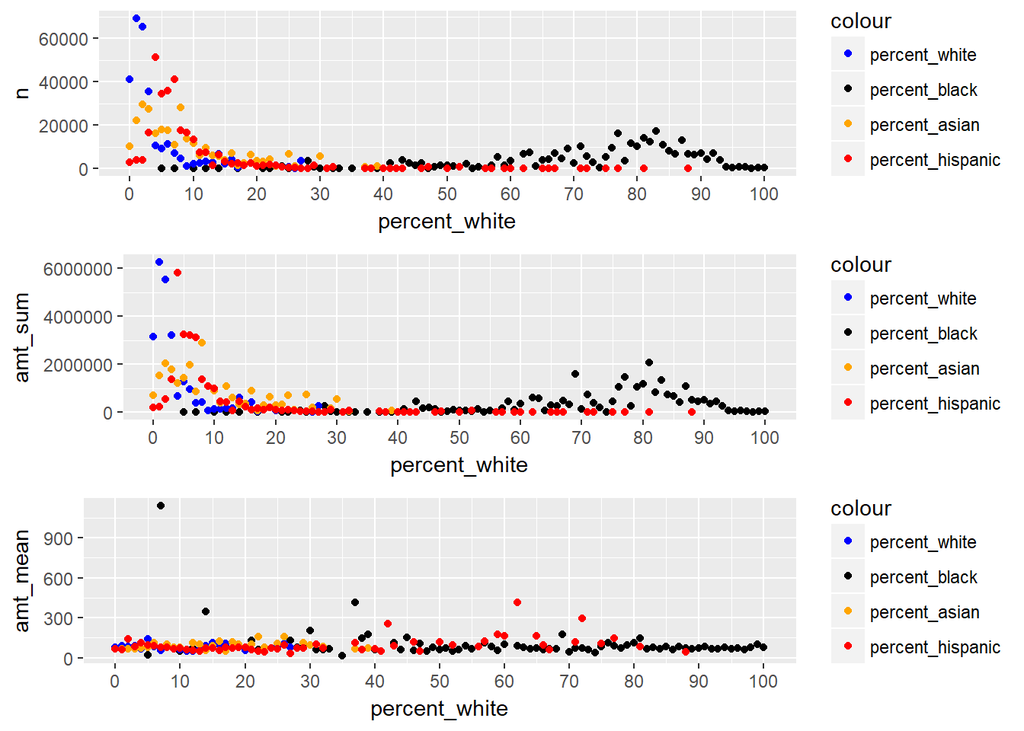

It seems hard to interpret.

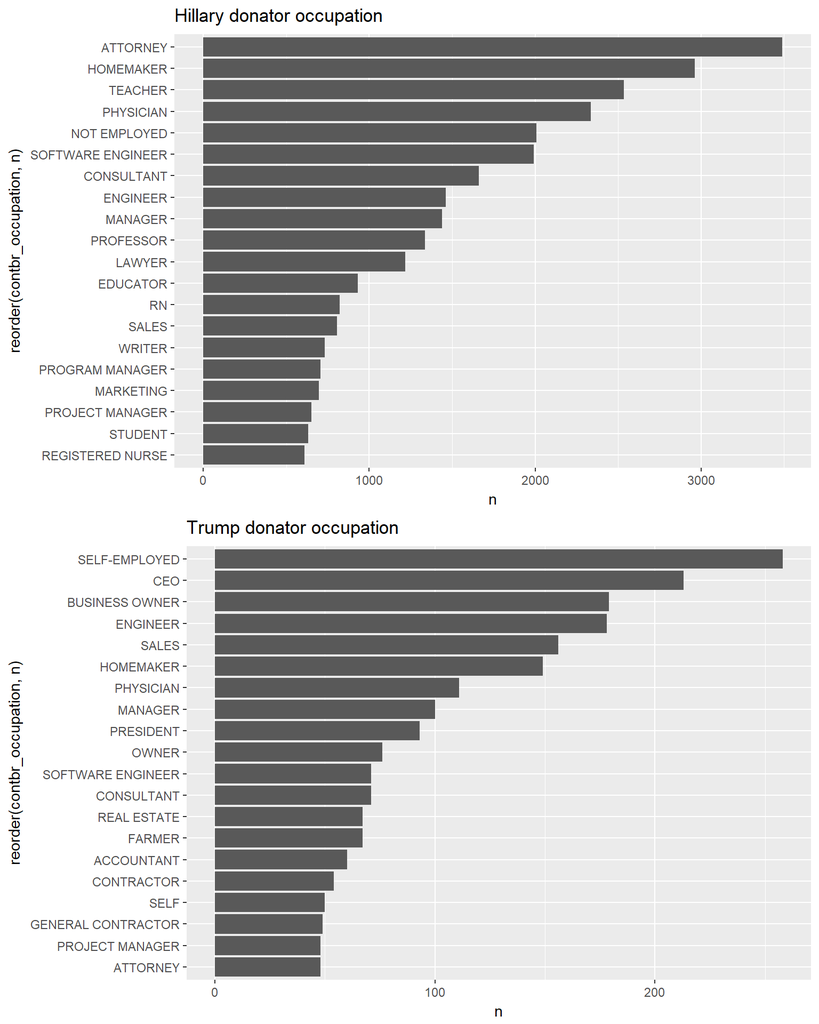

That is very interesting! There is strong and interesting relation between contributor occupation and candidate’s backgroud.

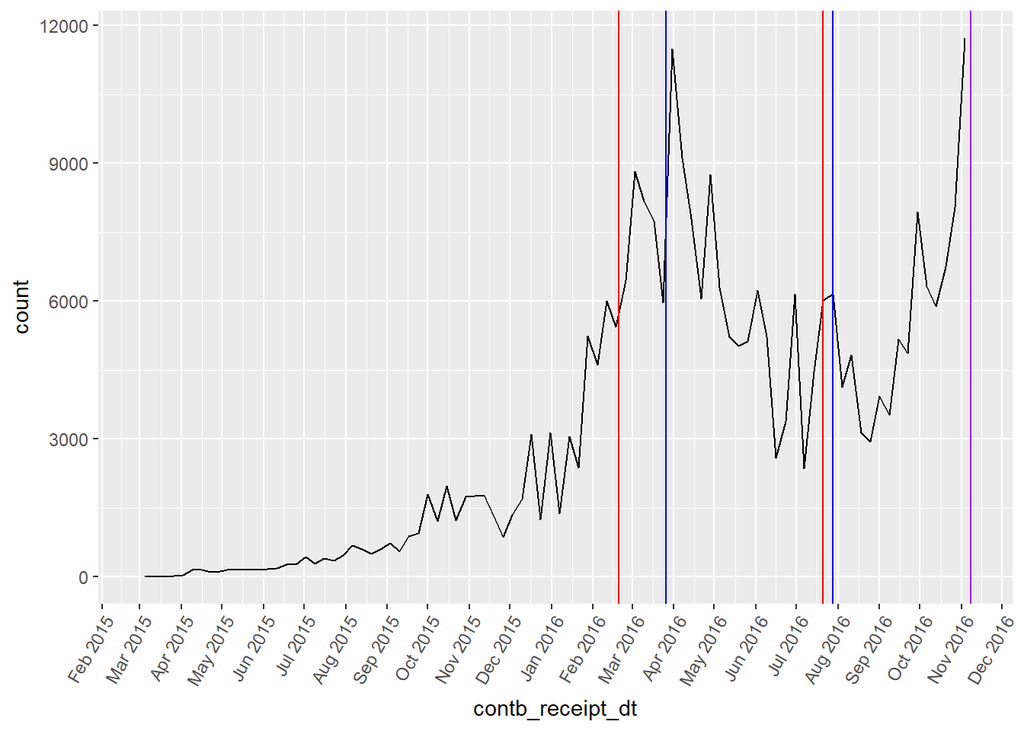

People make more and more contribution when the election day and other big day are closer and closer. I wonder what that valley is.

# Bivariate Analysis

### Talk about some of the relationships you observed in this part of the investigation. How did the feature(s) of interest vary with other features in the dataset?

contb_receipt_amt and party have 0.135 correlationorrelation. contb_receipt_amt and election_tp have -0.105 correlationorrelation.  
contb_receipt_amt and per_capital_income have 0.133 correlationorrelation.

Democrat’s total contribution is more than Republican, but Replublican’s mean contribution is more than Democrat.

People have around 70000 income make the most contribution.

Male make more contribution than female on both sum and mean, but not much.

There is some high contribution outlier at low income, which seems very weird.  
people about 40 make the most contribution, but the people about 30 make the highest median contribution. There is one weird peak at about 22 in sum contribution.  
There are also two other peaks at 25 and 60 in median contribution.

There is strong and interesting relation between contributor occupation and candidate’s backgroud.

People make more and more contribution when the election day and other big day are closer and closer.

### Did you observe any interesting relationships between the other features (not the main feature(s) of interest)?

cand_gender and contbr_gender have 0.339 correlation  
cand_gender and per_capita_income have -0.214 correlation  
party and per_capita_income have -0.216 correlation  
party and percent_black have -0.154 correlation  
party and percent_asian have -0.181 correlation  
party and percent_hispanic have 0.146 correlation  
total_population and median_age have -0.523 correlation  
total_popultation and percent_white have -0.316 correlation  
total_popultation and percent_black 0.139 correlation  
total_popultation and percent_asian have 0.31 correlation  
total_popultation and percent_hispanic have 0.199 correlation  
percent_white and percent_black have -0.777 correlation  
percent_white and percent_asian have -0.755 correlation  
percent_white and percent_hispanic have -0.531 correlation  
percent_asian and per_capita_income have 0.232 correlation  
percent_asian and median_rent have 0.437 correlation  
percent_asian and median_age have -0.28 correlation  
percent_hispanic and median_rent have -0.328 correlation  
percent_hispanic and median_age have -0.318 correlation  
percent_hispanic and per_capita_income have -0.409 correlation  
per_capita_income and median_rent have 0.762 correlation

### What was the strongest relationship you found?

percent_white and percent_black have -0.777 correlation, even higher than 0.762 correlation between per_capita_income and median_rent have

# Multivariate Plots Section

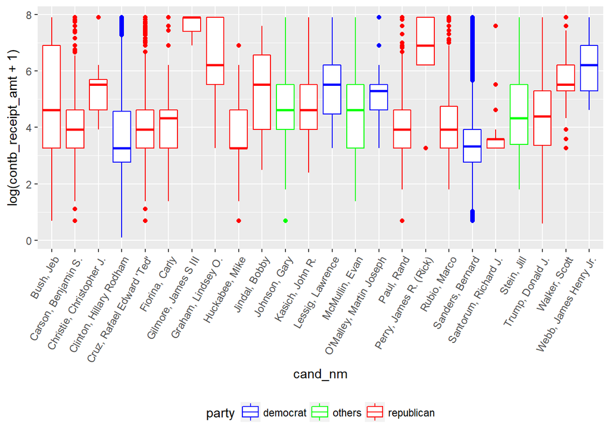

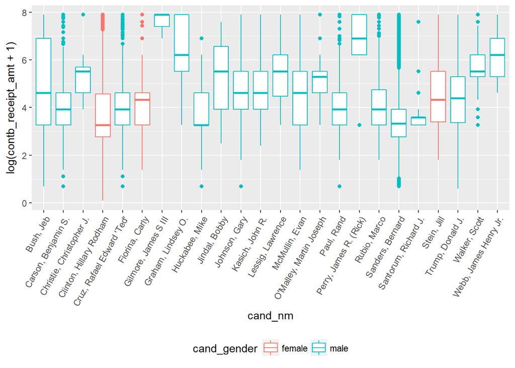

The distribution of each candidate’s contribution, colored by gender.

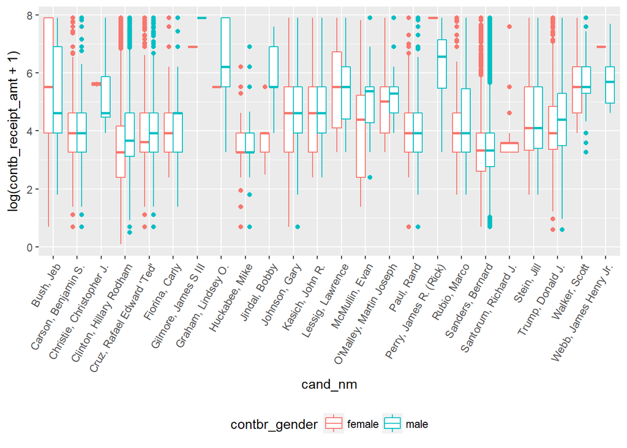

The distribution of each candidate’s contribution, colored and paired by donator’s gender. Both Trump and Hillary are more welcome by male rather than female.

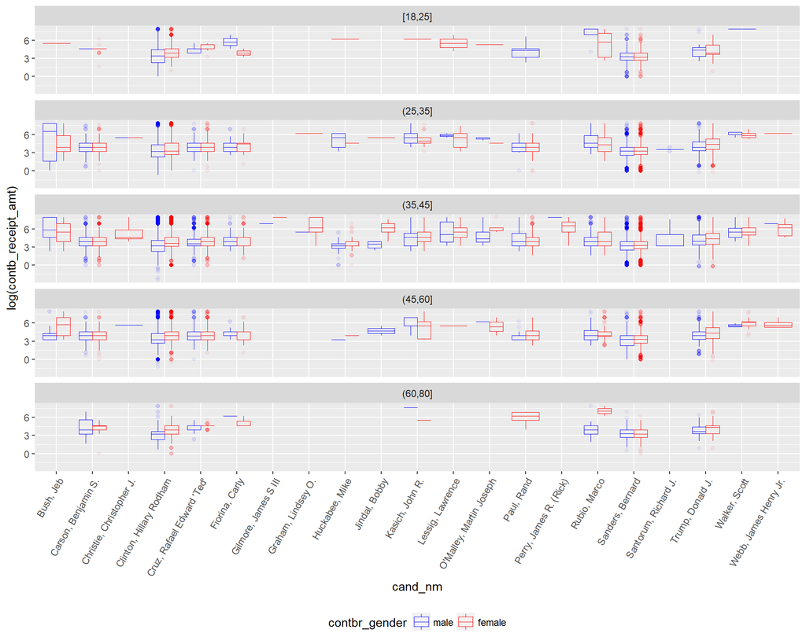

The distribution of each candidate’s contribution, colored by donator’s gender and faceted by median age.

Moreover, I try to build a linear model to predict contribution. But it seems not good.

```
##
## Calls:
## m1: lm(formula = contb_receipt_amt ~ per_capita_income, data = wa)
## m2: lm(formula = contb_receipt_amt ~ per_capita_income + contbr_gender,
##     data = wa)
## m3: lm(formula = contb_receipt_amt ~ per_capita_income + contbr_gender +
##     party, data = wa)
## m4: lm(formula = contb_receipt_amt ~ per_capita_income + contbr_gender +
##     party + median_age, data = wa)
## m5: lm(formula = contb_receipt_amt ~ per_capita_income + contbr_gender +
##     party + median_age + percent_white, data = wa)
##
## =====================================================================================================
##                           m1              m2              m3              m4              m5
## -----------------------------------------------------------------------------------------------------
##   (Intercept)         -9.646***       -18.461***      -36.857***       -5.524          10.220**
##                       (1.403)          (1.489)         (1.517)         (3.112)         (3.349)
##   per_capita_income    0.003***         0.003***        0.003***        0.003***        0.003***
##                       (0.000)          (0.000)         (0.000)         (0.000)         (0.000)
##   contbr_gendermale                    20.036***       12.929***       12.442***       12.146***
##                                        (0.929)         (0.931)         (0.932)         (0.932)
##   partyothers                                         174.332***      175.027***      175.156***
##                                                        (6.814)         (6.813)         (6.811)
##   partyrepublican                                      71.136***       72.050***       73.165***
##                                                        (1.329)         (1.331)         (1.334)
##   median_age                                                           -0.848***       -0.422***
##                                                                        (0.074)         (0.081)
##   percent_white                                                                        -0.464***
##                                                                                        (0.037)
## -----------------------------------------------------------------------------------------------------
##   R-squared                   0.018           0.019           0.031           0.032           0.033
##   adj. R-squared              0.018           0.019           0.031           0.032           0.033
##   sigma                     242.979         241.651         240.144         240.086         240.015
##   F                        5113.117        2676.403        2213.295        1798.083        1526.156
##   p                           0.000           0.000           0.000           0.000           0.000
##   Log-likelihood       -1970336.620    -1881166.331    -1879460.552    -1879394.094    -1879313.501
##   Deviance          16829704435.971 15905510725.251 15707535943.265 15699872892.314 15690584822.102
##   AIC                   3940679.240     3762340.662     3758933.104     3758802.189     3758643.001
##   BIC                   3940710.922     3762382.722     3758996.193     3758875.793     3758727.121
##   N                      285064          272379          272379          272379          272379
## =====================================================================================================
```

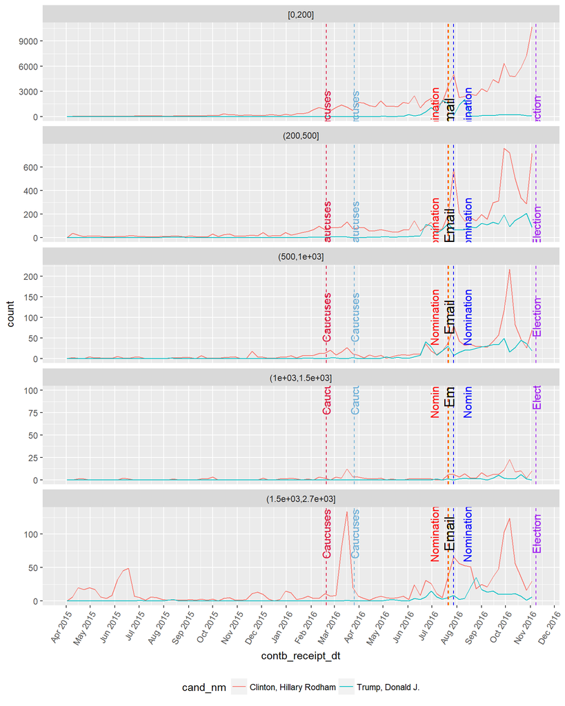

Hillary’s contribution went down to a valley after email controversy and then went up. After the peak at around first week in October, the contribution slump down. Cannot figure out why. Trump’s contribution is steadily low compared with Hillary.

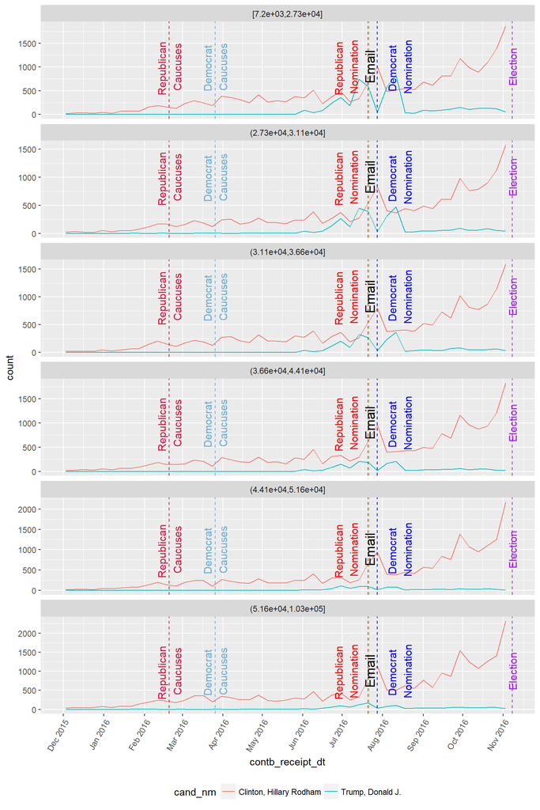

Almost the same trend regardless of per capita income!